# Dự báo chuỗi thời: Coffee Sales

Vietnamese version

Trần Trọng Phúc

12 Tháng 10 2025

# 1 Giới thiệu

Dữ liệu [`coffee-sales`](https://www.kaggle.com/datasets/ihelon/coffee-sales) trên kaggle gồm 2 file `index_1.csv` và `index_2.csv`.

| Tên biến | Mô tả |
| --- | --- |
| `date` | Ngày bán |
| `datetime` | Giờ bán |
| `cash_type` | Hình thức thanh toán |
| `card` | Mã thẻ nếu thanh toán bằng thẻ |
| `money` | Số tiền thanh toán |
| `coffee_name` | Tên ca phê |

Dưới đây là một số gói lệnh cần thiết cho quá trình phân tích.

```r
if (!require("pacman")) install.packages("pacman")
pacman::p_load(lubridate, dplyr, ggplot2, plotly, readxl, TSstudio, xts, tseries, forecast)
coffee <- read.csv("index_1.csv", header = T)
```

```r
coffee$date <- as.Date(coffee$date)
head(coffee)
```

```
##         date                datetime cash_type                card money
## 1 2024-03-01 2024-03-01 10:15:50.520      card ANON-0000-0000-0001  38.7
## 2 2024-03-01 2024-03-01 12:19:22.539      card ANON-0000-0000-0002  38.7
## 3 2024-03-01 2024-03-01 12:20:18.089      card ANON-0000-0000-0002  38.7
## 4 2024-03-01 2024-03-01 13:46:33.006      card ANON-0000-0000-0003  28.9
## 5 2024-03-01 2024-03-01 13:48:14.626      card ANON-0000-0000-0004  38.7
## 6 2024-03-01 2024-03-01 15:39:47.726      card ANON-0000-0000-0005  33.8
##           coffee_name
## 1               Latte
## 2       Hot Chocolate
## 3       Hot Chocolate
## 4           Americano
## 5               Latte
## 6 Americano with Milk
```

```r
options(repr.plot.width = 16, repr.plot.height = 8)
# ------------------ #
coffee %>% group_by(cash_type) %>%
  count() %>% summarise(percent = round(n/nrow(coffee)*100,2))
```

```
## # A tibble: 2 × 2
##   cash_type percent
##   <chr>       <dbl>
## 1 card        97.6
## 2 cash         2.45
```

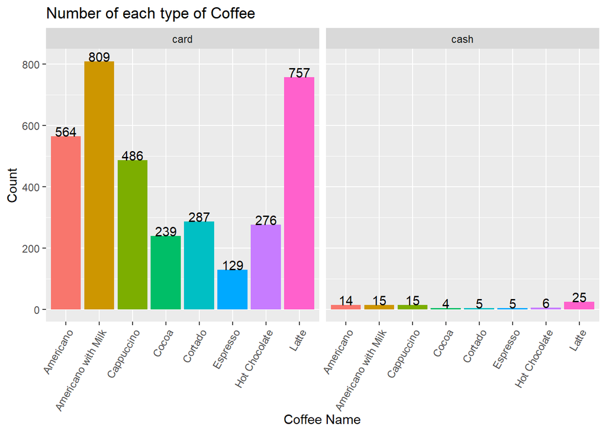

```r
ggplot(coffee, mapping = aes(x = coffee_name, fill = coffee_name)) +
  geom_bar() + facet_wrap( ~ cash_type) +
  geom_text(stat = 'count', aes(label = ..count..), vjust = "bottom") +
  labs(x = "Coffee Name", y = "Count", title = "Number of each type of Coffee") +
  theme(axis.text.x = element_text(angle = 60, hjust = 1), legend.position="none")
```

Doanh thu theo tháng

```r
fig <- coffee %>% mutate(time = as.Date(format(date, "%Y-%m-01"))) %>%
  group_by(time) %>%
  summarise(sales = sum(money)) %>%
  ggplot(mapping = aes(x = time, y = sales)) +
  geom_line(linewidth = 0.8, color = "blue") +
  geom_point(color = "darkblue") +
  labs(x = "Tháng", y = "Tổng", title = "Doanh thu theo tháng")
ggplotly(fig)
```

[interactive chart not shown]

# 2 Xây dựng mô hình dự báo

```r
cfSales <- coffee %>%
    group_by(date = date) %>%
    summarise(sales = sum(money))
head(cfSales)
```

```
## # A tibble: 6 × 2
##   date       sales
##   <date>     <dbl>
## 1 2024-03-01  396.
## 2 2024-03-02  228.
## 3 2024-03-03  349.
## 4 2024-03-04  135.
## 5 2024-03-05  338.
## 6 2024-03-06  170.
```

## 2.1 Xử dụng hàm tự động

Sử dụng hàm `auto.arima()`.

```r
ts <- xts(cfSales$sales, order.by = cfSales$date)
ts_info(ts)
```

```
##  The ts series is a xts object with 1 variable and 381 observations
##  Frequency: daily
##  Start time: 2024-03-01
##  End time: 2025-03-23
```

```r
ts_plot(ts)
```

[interactive chart not shown]

Tạo tập huấn luyện và tập kiểm tra

```r
h1 <- 40 # Size of the test data
h2 <- 30 # Number of forecast periods
# -------------- #

# Create data train and data test
ts_train <- ts[c(1:(nrow(cfSales) - h1))]
ts_test <- ts[c((nrow(cfSales) - h1 +1): nrow(cfSales))]
# -------------- #

# Using function auto.arima()
arima_md <- auto.arima(ts_train)
fc_arima_md <- forecast(arima_md, h = h1)
# -------------- #

# Result
test_forecast(ts,
              forecast.obj = fc_arima_md,
              test = ts_test)
```

[interactive chart not shown]

## 2.2 Xây dựng mô hình thủ công

```r
diff1 <- diff(cfSales$sales)
suppressWarnings(adf.test(diff1))
```

```
##
##  Augmented Dickey-Fuller Test
##
## data:  diff1
## Dickey-Fuller = -10.241, Lag order = 7, p-value = 0.01
## alternative hypothesis: stationary
```

`giá trị p = 0,01 < 0,05`, do đó chúng ta chấp nhận giả thuyết chuỗi dừng. Vì vậy, chọn `d = 1 = D`.

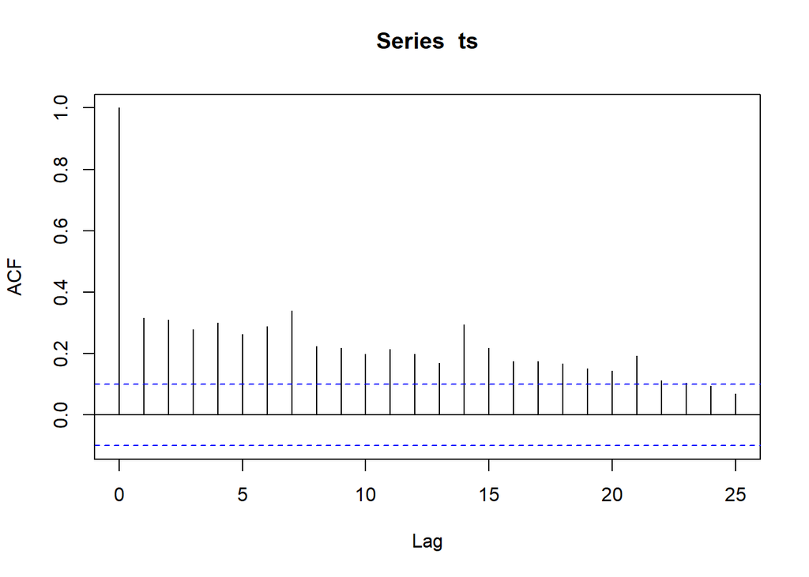

```r
acf(ts)
```

`lag` giảm dần, nhưng chúng ta có thể thấy `lag = 7` và `lag = 14` cao hơn đáng kể trong cả biểu đồ ACF và PACF. Điều này cho thấy chúng ta có thể tạo tần suất tạm thời là 7 cho chuỗi thời gian.

**Với biểu đồ ACF** bỏ qua `lag = 0`, ta có

- Ba độ trễ đầu tiên giảm dần sau đó `lag = 4` có hệ số cao hơn, vì vây ta chọn `p = 3`
- Sau `lag = 7, lag = 14`, rất khó để xác định độ trễ nào là phù hợp; tránh chọn độ trễ quá lớn, do đó chúng ta chọn `P = 1` (Vì `lag/frequency = 7/7`).

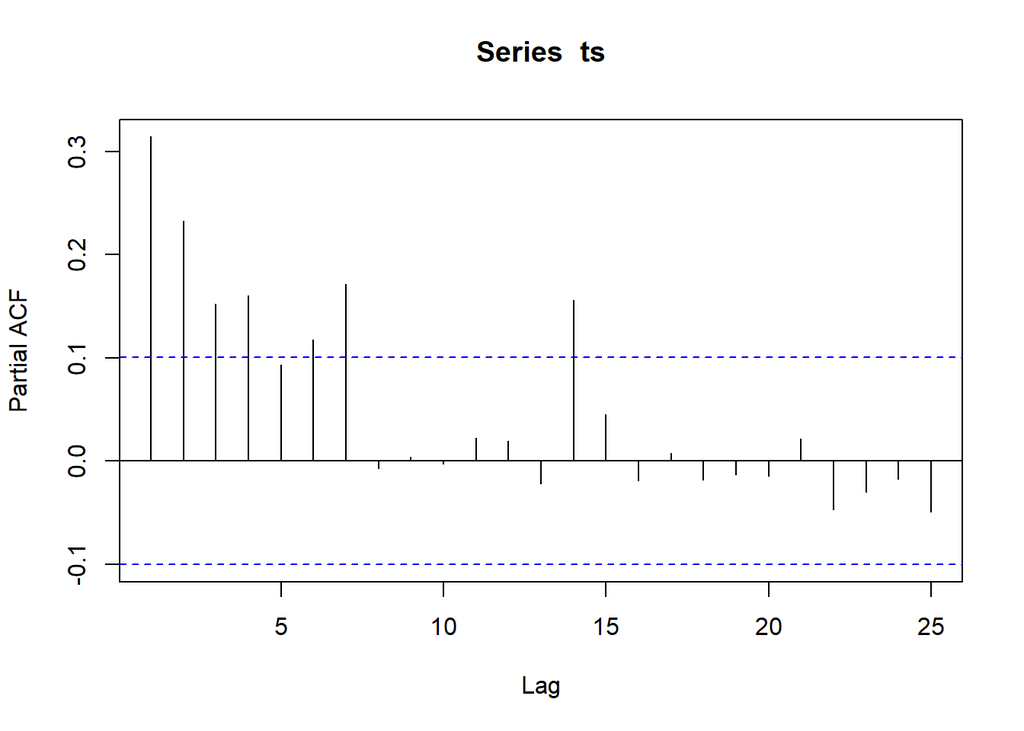

```r
pacf(ts)
```

```r
md_hand <- arima(ts_train, order = c(3,1,2), seasonal = list(order = c(1,1,0), period = 7))
fc_md_hand <- forecast(md_hand, h = h1)
print("ARIMA(3,1,2)(1,1,0)[7]"); round(accuracy(fc_md_hand, ts_test),2)
```

```
## [1] "ARIMA(3,1,2)(1,1,0)[7]"
```

```
##                 ME   RMSE    MAE    MPE  MAPE MASE  ACF1
## Training set  6.77 159.07 123.26 -34.45 68.37 0.86 -0.01
## Test set     -6.94 115.57  87.88 -10.80 24.65 0.62    NA
```

Với các tiêu chí cho tập kiểm tra (càng nhỏ càng tốt) bao gồm:

- MAE (Mean Absolute Error): Trung bình tuyệt dối sai số
  $$\dfrac{1}{n}\sum\limits_{i=1}^n|y_{\text{actualy}}-y_{\text{perdict}}|$$
  .
- MAPE (Mean Absolute Percentage Error): Trung bình phân trăm sai số tuyệt đối
  $$\dfrac{1}{n}\sum\limits_{i=1}^n\dfrac{|y_{\text{actualy}}-y_{\text{perdict}}|}{y_{\text{actualy}}}\times100$$

**–> Mô hình này khá tốt**

```r
test_forecast(ts,
              forecast.obj = fc_md_hand,
              test = ts_test)
```

[interactive chart not shown]

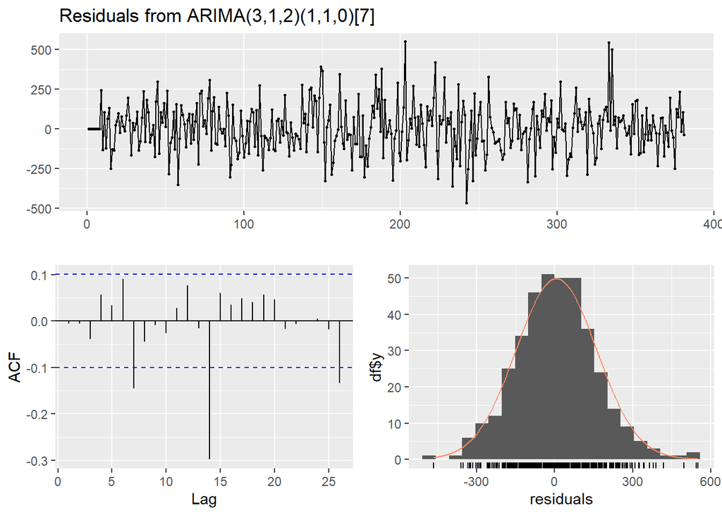

```
##
##  Ljung-Box test
##
## data:  Residuals from ARIMA(3,1,2)(1,1,0)[7]
## Q* = 14.756, df = 4, p-value = 0.005234
##
## Model df: 6.   Total lags used: 10
```

```r
final_md <- arima(cfSales$sales, order = c(3,1,2),
                  seasonal = list(order = c(1,1,0), period = 7))
checkresiduals(final_md)
```

```r
fc_final_md <- forecast(final_md, h = h2)
plot_forecast(fc_final_md)
```

[interactive chart not shown]

`p-value = 0.005234 < 0.05` của kiểm định Ljung-Box cho thấy phần dư của mô hình không thực sự tốt.

# 3 Áp dụng cho dữ liệu còn lại

```r
coffee <- read.csv("index_2.csv", header = T)

coffee$date <- as.Date(coffee$date)
head(coffee)
```

```
##         date            datetime cash_type money           coffee_name
## 1 2025-02-08 2025-02-08 14:26:04      cash    15                   Tea
## 2 2025-02-08 2025-02-08 14:28:26      cash    15                   Tea
## 3 2025-02-08 2025-02-08 14:33:04      card    20              Espresso
## 4 2025-02-08 2025-02-08 15:51:04      card    30 Chocolate with coffee
## 5 2025-02-08 2025-02-08 16:35:01      cash    27   Chocolate with milk
## 6 2025-02-08 2025-02-08 18:55:30      card    33              Espresso
```

```r
cfSales <- coffee %>%
    group_by(date = date) %>%
    summarise(sales = sum(money))
head(cfSales)
```

```
## # A tibble: 6 × 2
##   date       sales
##   <date>     <dbl>
## 1 2025-02-08   196
## 2 2025-02-09   444
## 3 2025-02-10    77
## 4 2025-02-11    40
## 5 2025-02-12    27
## 6 2025-02-13   120
```

```r
ts <- xts(cfSales$sales, order.by = cfSales$date)
ts_info(ts)
```

```
##  The ts series is a xts object with 1 variable and 41 observations
##  Frequency: daily
##  Start time: 2025-02-08
##  End time: 2025-03-23
```

```r
ts_plot(ts)
```

[interactive chart not shown]

Tạo tập huấn luyện và tập kiểm tra

```r
h1 <- 10 # Size of the test data
h2 <- 10 # Number of forecast periods
# -------------- #

# Create data train and data test
ts_train <- ts[c(1:(nrow(cfSales) - h1))]
ts_test <- ts[c((nrow(cfSales) - h1 +1): nrow(cfSales))]
# -------------- #

# Using function auto.arima()
arima_md <- auto.arima(ts_train)
fc_arima_md <- forecast(arima_md, h = h1)
# -------------- #

# Result
test_forecast(ts,
              forecast.obj = fc_arima_md,
              test = ts_test)
```

[interactive chart not shown]

```r
adf.test(ts)
```

```
##
##  Augmented Dickey-Fuller Test
##
## data:  ts
## Dickey-Fuller = -4.8135, Lag order = 3, p-value = 0.01
## alternative hypothesis: stationary
```

`giá trị p = 0,01 < 0,05`, do đó chúng ta chấp nhận giả thuyết chuỗi dừng. Vì vậy, chọn `d = 0 = D`.

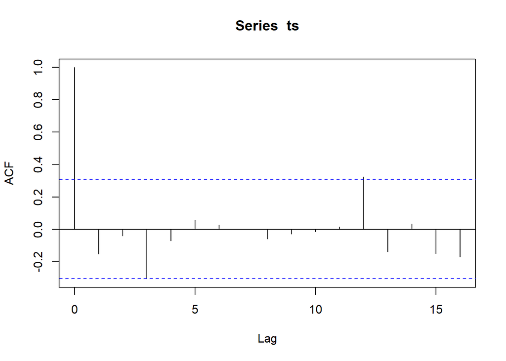

```r
acf(ts)
```

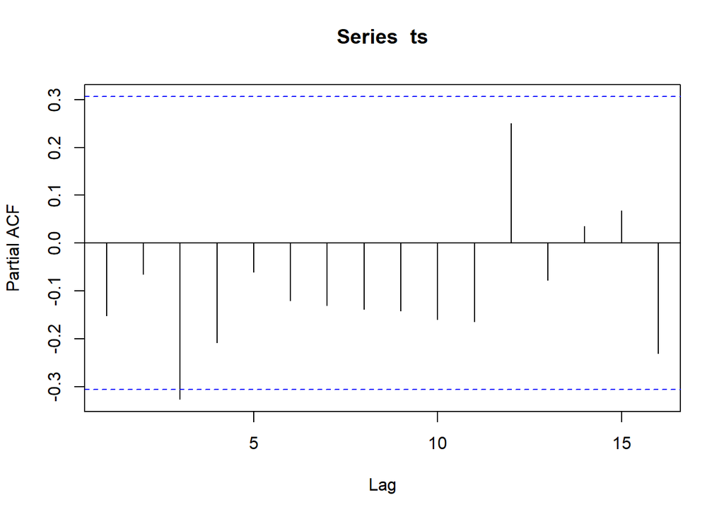

```r
pacf(ts)
```

**Với biểu đồ PACF** (không có `lag = 0`), ta có

Ở phần trước ta đã xác định các hệ số mùa nên bây giờ ta sẽ dùng lại nó chỉ cần thay đổi `D = 0`.

```r
md_hand <- arima(ts_train, order = c(3,0,2),
                 seasonal = list(order = c(1,0,0), period = 7))
fc_md_hand <- forecast(md_hand, h = h2)
print("ARIMA(3,0,2)(1,0,0)[7]"); round(accuracy(fc_md_hand, ts_test),2)
```

```
## [1] "ARIMA(3,0,2)(1,0,0)[7]"
```

```
##                  ME  RMSE   MAE    MPE  MAPE MASE  ACF1
## Training set  -7.05 77.53 62.94 -39.19 59.67 0.56 -0.02
## Test set     -12.14 61.28 54.60 -23.14 39.95 0.49    NA
```

```r
test_forecast(ts,
              forecast.obj = fc_md_hand,
              test = ts_test)
```

[interactive chart not shown]

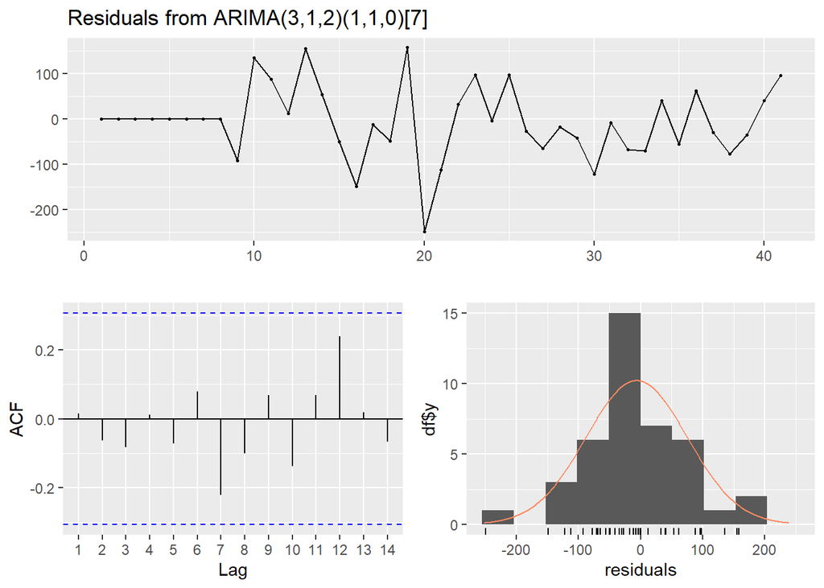

```
##
##  Ljung-Box test
##
## data:  Residuals from ARIMA(3,1,2)(1,1,0)[7]
## Q* = 4.3946, df = 3, p-value = 0.2219
##
## Model df: 6.   Total lags used: 9
```

```r
final_md <- arima(cfSales$sales, order = c(3,1,2),
                  seasonal = list(order = c(1,1,0), period = 7))
checkresiduals(final_md)
```

```r
fc_final_md <- forecast(final_md, h = h2)
plot_forecast(fc_final_md)
```

[interactive chart not shown]